# IE582-HW2-v2

```python
import pandas as pd
import numpy as np
import matplotlib.pyplot as plt
from sklearn.tree import DecisionTreeClassifier,DecisionTreeRegressor
from sklearn.model_selection import train_test_split,GridSearchCV
from sklearn.metrics import f1_score, precision_score,recall_score,accuracy_score, mean_squared_error
from sklearn.datasets import load_breast_cancer, fetch_openml
from sklearn.ensemble import RandomForestRegressor,GradientBoostingClassifier,RandomForestClassifier
from sklearn.neighbors import KNeighborsClassifier,KNeighborsRegressor
from ucimlrepo import fetch_ucirepo
import warnings
import scipy.io
import keras
from sklearn.decomposition import PCA
import h5py
warnings.filterwarnings("ignore")
```

```python
def test_results(pred_y,true_y):
    """
    Perform GridSearchCV for a given model and hyperparameter grid.

    Parameters:
    - model: The machine learning model (e.g., DecisionTreeClassifier, RandomForestClassifier, etc.).
    - param_grid: Dictionary of hyperparameters and their possible values.
    - X_train, y_train: Training data and labels.
    - X_test, y_test: Testing data and labels.
    - cv: Number of folds for cross-validation.
    - scoring: The evaluation metric to optimize.

    Returns:
    - best_params: Best hyperparameters found by GridSearchCV.
    - test_results_dict: Test results dictionary.
    """

    return {"test_accuracy": accuracy_score(true_y, pred_y),
             "precision": precision_score(true_y, pred_y, average='weighted',zero_division=1),
             "recall_score": recall_score(true_y, pred_y, average='weighted'),
              "f1_score": f1_score(true_y, pred_y, average='weighted')}
```

```python
def perform_grid_search(model, param_grid, X_train, y_train, X_test, y_test, cv=2, scoring='accuracy',is_regression=False):
    """
    Perform GridSearchCV for a given model and hyperparameter grid.

    Parameters:
    - model: The machine learning model (e.g., DecisionTreeClassifier, RandomForestClassifier, etc.).
    - param_grid: Dictionary of hyperparameters and their possible values.
    - X_train, y_train: Training data and labels.
    - X_test, y_test: Testing data and labels.
    - cv: Number of folds for cross-validation.
    - scoring: The evaluation metric to optimize.

    Returns:
    - best_params: Best hyperparameters found by GridSearchCV.
    - test_accuracy: Accuracy on the test set using the best hyperparameters.
    """


    grid_search = GridSearchCV(model, param_grid, cv=cv, scoring=scoring,return_train_score=True)
    grid_search.fit(X_train, y_train)


    best_params = grid_search.best_params_
    print("Best Hyperparameters:", best_params)

    cv_results = grid_search.cv_results_

    best_model = grid_search.best_estimator_
    y_pred = best_model.predict(X_test)

    if is_regression:
        test_results_dict = mean_squared_error(y_test, y_pred)
        print("Mean Squared Error after GridSearch:", test_results_dict)
    else:
        test_results_dict = test_results(y_pred, y_test)
        print("Test Results after GridSearch:", test_results_dict)

    return best_params, cv_results, test_results_dict
```

```python
 def plot_grid_search(cv_results, params,is_regression=False):
        param_values = [str(param) for param in cv_results["params"]]
        xlabel = str(list(params.keys()))

        mean_train_scores = cv_results['mean_train_score']
        mean_test_scores = cv_results['mean_test_score']


        # plot
        if is_regression==0:
            plt.figure(figsize=(12, 6))
            plt.plot(param_values, (1 - mean_train_scores)*100, 'o-', label='Mean Training Error')
            plt.plot(param_values, (1 - mean_test_scores)*100, 'o-', label='Mean Testing Error')
            plt.title('Mean Training and Testing Accuracy for Different ' + xlabel + ' values (GridSearchCV)')
            plt.xlabel('Parameter Values')
            plt.ylabel('Error (%)')
            plt.legend()
            plt.xticks(rotation=45, ha='right')  # Rotate x-axis labels for better visibility
            plt.grid(True)
            plt.tight_layout()
            plt.show()

        elif is_regression==1:
            plt.figure(figsize=(12, 6))
            plt.plot(param_values, (mean_train_scores), 'o-', label='Mean Training Error')
            plt.plot(param_values, (mean_test_scores), 'o-', label='Mean Testing Error')
            plt.title('Neg MSE for Different ' + xlabel + ' values (GridSearchCV)')
            plt.xlabel('Parameter Values')
            plt.ylabel('Negative Mean Squared Error')
            plt.legend()
            plt.xticks(rotation=45, ha='right')  # Rotate x-axis labels for better visibility
            plt.grid(True)
            plt.tight_layout()
            plt.show()
```

```python
def decision_tree(X_train,y_train,X_test,y_test):

    dt = DecisionTreeClassifier(min_samples_leaf=5)
    dt.fit(X_train,y_train)
    y_predict= dt.predict(X_test)
    result=test_results(y_predict,y_test)
    print(f"""Decision Tree model performance before GridSearch: {result}""")

    # Define the hyperparameters to tune
    param_grid = {
     # Minimal number of observations per tree leaf
    'min_samples_leaf': [1, 5, 10, 20, 30],
     # Complexity parameter set to zero as stated in assignment
    'ccp_alpha': [0],
     # Minimum number of observations to split
    'min_samples_split': [2, 10, 20, 40, 60] }
    best_params, cv_results, test_results_dict=perform_grid_search(dt, param_grid, X_train, y_train, X_test, y_test)

    plot_grid_search(cv_results,param_grid)

    return best_params, cv_results, test_results_dict
```

```python
def random_forest(X_train,y_train,X_test,y_test):

    rf = RandomForestClassifier(n_estimators=500,min_samples_leaf=5,n_jobs=-1)
    rf.fit(X_train,y_train)
    y_predict= rf.predict(X_test)

    result=test_results(y_predict,y_test)
    print(f"""Random forest model performance before GridSearch: {result}""")

    param_grid = {
     # Number of trees
    'n_estimators': [500],
    # Number of max_features
    'max_features': ['sqrt', 'log2', 0.5, 0.9, 1.0],
    # Minimal number of observations per tree leaf
    'min_samples_leaf': [5] }

    best_params, cv_results, test_results_dict=perform_grid_search(rf, param_grid, X_train, y_train, X_test, y_test)

    plot_grid_search(cv_results,param_grid)

    return best_params, cv_results, test_results_dict
```

```python
def knn_function(X_train,y_train,X_test,y_test):

    X_train_array = X_train.to_numpy()
    X_test_array = X_test.to_numpy()
    y_train_array = y_train.to_numpy()
    y_test_array = y_test.to_numpy()

    knn_classifier = KNeighborsClassifier(n_neighbors=3)
    knn_classifier.fit(X_train_array, y_train_array)
    y_predict= knn_classifier.predict(X_test_array)
    result=test_results(y_predict,y_test_array)
    print(f"""kNN model performance before GridSearch: {result}""")

    param_grid = {
    'n_neighbors': [3,10,20],
    'p': [1, 2] }

    best_params, cv_results, test_results_dict=perform_grid_search(knn_classifier, param_grid, X_train_array, y_train_array, X_test_array, y_test_array)

    plot_grid_search(cv_results,param_grid)

    return best_params, cv_results, test_results_dict
```

```python
def xgboost_function(X_train,y_train,X_test,y_test):

    xgb = GradientBoostingClassifier(max_depth=30,n_estimators=100, learning_rate=0.1)

    xgb.fit(X_train,y_train)

    y_predict= xgb.predict(X_test)
    result=test_results(y_predict,y_test)
    print(f"""XGBoost model performance before GridSearch: {result}""")

    param_grid = {
    #Maximum depth of the individual regression estimators
    'max_depth': [5, 10, 20, 100],
    #The number of boosting stages to perform
    'n_estimators': [50, 100, 200],
    #Learning rate shrinks the contribution of each tree by learning_rate
    'learning_rate': [0.01, 0.1, 0.5,1]
}

    best_params, cv_results, test_results_dict=perform_grid_search(xgb, param_grid, X_train, y_train, X_test, y_test)

    plot_grid_search(cv_results,param_grid)

    return best_params, cv_results, test_results_dict
```

# Task: Classification with Imbalanced Class

This dataset comprises data gathered from trees in four regions of the Roosevelt National Forest in Colorado. All recorded variables are cartographic in nature, with no utilization of remote sensing, and originate from 30-meter by 30-meter portions of the forest.

```python
data = pd.read_csv('covtype.csv')
data.head()
```

|  | Elevation | Aspect | Slope | Horizontal_Distance_To_Hydrology | Vertical_Distance_To_Hydrology | Horizontal_Distance_To_Roadways | Hillshade_9am | Hillshade_Noon | Hillshade_3pm | Horizontal_Distance_To_Fire_Points | ... | Soil_Type32 | Soil_Type33 | Soil_Type34 | Soil_Type35 | Soil_Type36 | Soil_Type37 | Soil_Type38 | Soil_Type39 | Soil_Type40 | Cover_Type |
| --- | --- | --- | --- | --- | --- | --- | --- | --- | --- | --- | --- | --- | --- | --- | --- | --- | --- | --- | --- | --- | --- |
| 0 | 2596 | 51 | 3 | 258 | 0 | 510 | 221 | 232 | 148 | 6279 | ... | 0 | 0 | 0 | 0 | 0 | 0 | 0 | 0 | 0 | 5 |
| 1 | 2590 | 56 | 2 | 212 | -6 | 390 | 220 | 235 | 151 | 6225 | ... | 0 | 0 | 0 | 0 | 0 | 0 | 0 | 0 | 0 | 5 |
| 2 | 2804 | 139 | 9 | 268 | 65 | 3180 | 234 | 238 | 135 | 6121 | ... | 0 | 0 | 0 | 0 | 0 | 0 | 0 | 0 | 0 | 2 |
| 3 | 2785 | 155 | 18 | 242 | 118 | 3090 | 238 | 238 | 122 | 6211 | ... | 0 | 0 | 0 | 0 | 0 | 0 | 0 | 0 | 0 | 2 |
| 4 | 2595 | 45 | 2 | 153 | -1 | 391 | 220 | 234 | 150 | 6172 | ... | 0 | 0 | 0 | 0 | 0 | 0 | 0 | 0 | 0 | 5 |

5 rows × 55 columns

```python
data.info()
```

```
<class 'pandas.core.frame.DataFrame'>
RangeIndex: 581012 entries, 0 to 581011
Data columns (total 55 columns):
 #   Column                              Non-Null Count   Dtype
---  ------                              --------------   -----
 0   Elevation                           581012 non-null  int64
 1   Aspect                              581012 non-null  int64
 2   Slope                               581012 non-null  int64
 3   Horizontal_Distance_To_Hydrology    581012 non-null  int64
 4   Vertical_Distance_To_Hydrology      581012 non-null  int64
 5   Horizontal_Distance_To_Roadways     581012 non-null  int64
 6   Hillshade_9am                       581012 non-null  int64
 7   Hillshade_Noon                      581012 non-null  int64
 8   Hillshade_3pm                       581012 non-null  int64
 9   Horizontal_Distance_To_Fire_Points  581012 non-null  int64
```

[output cut: 47 more lines]

```python
#split feature columns and target column
X = data.iloc[:,:-1]
y = data['Cover_Type']
```

```python
#check for class imbalance
class_labels = ['Spruce/Fir', 'Lodgepole Pine', 'Ponderosa Pine','Cottonwood/Willow', 'Aspen', 'Douglas-fir', 'Krummholz']
y.index = list(map(lambda i: class_labels[i - 1], y))
y.value_counts()
```

```
2    283301
1    211840
3     35754
7     20510
6     17367
5      9493
4      2747
Name: Cover_Type, dtype: int64
```

As can be seen from previous value counts, this dataset contains highly imbalanced classes.Lodgepole Pine and Spruce/Fir have notably larger representations whereas Cottonwood/Willow have small proportion.Sine it contains highly imbalanced dataset, training set can be divided into train and validation set to perform good generalization with developed approach.

Each number in target represensts a class: 1:Spruce/Fir 2:Lodgepole Pine 3:Ponderosa Pine 4:Cottonwood/Willow 5:Aspen 6:Douglas-fir 7:Krummholz

```python
#define train and test split
X_train, X_test, y_train, y_test = train_test_split(X, y, test_size=0.3, random_state=15)
```

```python
print("Training set size:", len(X_train))
print("Test set size:", len(X_test))
```

```
Training set size: 406708
Test set size: 174304
```

[output not shown]

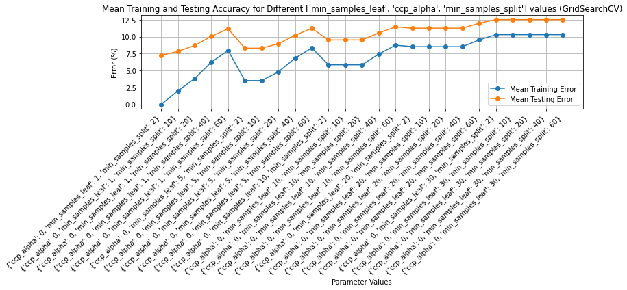

```python
#decision tree
best_params_f, cv_results_f, test_results_dict=decision_tree(X_train, y_train, X_test, y_test)
```

```
[1 1 2 ... 1 1 2]
Random forest model performance before GridSearch: {'test_accuracy': 0.9323767670277217, 'precision': 0.9329981544707718, 'recall_score': 0.9323767670277217, 'f1_score': 0.9316147698926971}
Best Hyperparameters: {'max_features': 0.9, 'min_samples_leaf': 5, 'n_estimators': 500}
Test Results after GridSearch: {'test_accuracy': 0.9587158068661649, 'precision': 0.958689811091893, 'recall_score': 0.9587158068661649, 'f1_score': 0.9585725884602544}
```

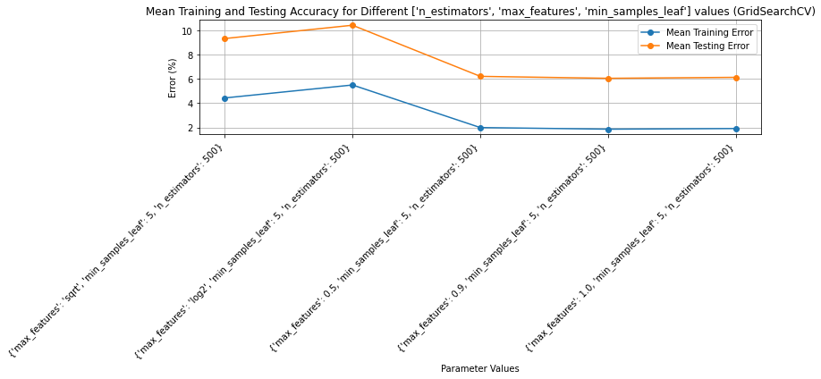

```python
#random forest
best_params_rf, cv_results_rf, test_results_dict_rf=random_forest(X_train, y_train, X_test, y_test)
```

```python
#knn
best_params_knn, cv_results_knn, test_results_dict_knn=knn_function(X_train, y_train, X_test, y_test)
```

[output not shown]

[output not shown]

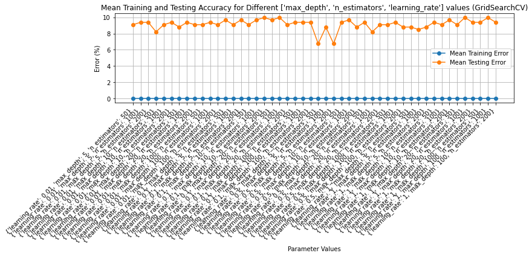

```python
#xgboost
best_params_xgb, cv_results_xgb, test_results_dict_xgb=xgboost_function(X_train, y_train, X_test, y_test)
```

# Task: Classification with Balanced Class

This dataset is a popular dataset for binary classification tasks, particularly for distinguishing between malignant and benign breast tumors. 1 represents malignant and 0 represents benign.

```python
data_breast_cancer = load_breast_cancer()
data = pd.DataFrame(data_breast_cancer.data, columns=data_breast_cancer.feature_names)
data['target']=data_breast_cancer.target
data.head()
```

|  | mean radius | mean texture | mean perimeter | mean area | mean smoothness | mean compactness | mean concavity | mean concave points | mean symmetry | mean fractal dimension | ... | worst texture | worst perimeter | worst area | worst smoothness | worst compactness | worst concavity | worst concave points | worst symmetry | worst fractal dimension | target |
| --- | --- | --- | --- | --- | --- | --- | --- | --- | --- | --- | --- | --- | --- | --- | --- | --- | --- | --- | --- | --- | --- |
| 0 | 17.99 | 10.38 | 122.80 | 1001.0 | 0.11840 | 0.27760 | 0.3001 | 0.14710 | 0.2419 | 0.07871 | ... | 17.33 | 184.60 | 2019.0 | 0.1622 | 0.6656 | 0.7119 | 0.2654 | 0.4601 | 0.11890 | 0 |
| 1 | 20.57 | 17.77 | 132.90 | 1326.0 | 0.08474 | 0.07864 | 0.0869 | 0.07017 | 0.1812 | 0.05667 | ... | 23.41 | 158.80 | 1956.0 | 0.1238 | 0.1866 | 0.2416 | 0.1860 | 0.2750 | 0.08902 | 0 |
| 2 | 19.69 | 21.25 | 130.00 | 1203.0 | 0.10960 | 0.15990 | 0.1974 | 0.12790 | 0.2069 | 0.05999 | ... | 25.53 | 152.50 | 1709.0 | 0.1444 | 0.4245 | 0.4504 | 0.2430 | 0.3613 | 0.08758 | 0 |
| 3 | 11.42 | 20.38 | 77.58 | 386.1 | 0.14250 | 0.28390 | 0.2414 | 0.10520 | 0.2597 | 0.09744 | ... | 26.50 | 98.87 | 567.7 | 0.2098 | 0.8663 | 0.6869 | 0.2575 | 0.6638 | 0.17300 | 0 |
| 4 | 20.29 | 14.34 | 135.10 | 1297.0 | 0.10030 | 0.13280 | 0.1980 | 0.10430 | 0.1809 | 0.05883 | ... | 16.67 | 152.20 | 1575.0 | 0.1374 | 0.2050 | 0.4000 | 0.1625 | 0.2364 | 0.07678 | 0 |

5 rows × 31 columns

```python
data.info()
```

```
<class 'pandas.core.frame.DataFrame'>
RangeIndex: 569 entries, 0 to 568
Data columns (total 31 columns):
 #   Column                   Non-Null Count  Dtype
---  ------                   --------------  -----
 0   mean radius              569 non-null    float64
 1   mean texture             569 non-null    float64
 2   mean perimeter           569 non-null    float64
 3   mean area                569 non-null    float64
 4   mean smoothness          569 non-null    float64
 5   mean compactness         569 non-null    float64
 6   mean concavity           569 non-null    float64
 7   mean concave points      569 non-null    float64
 8   mean symmetry            569 non-null    float64
 9   mean fractal dimension   569 non-null    float64
```

[output cut: 23 more lines]

```python
#split feature columns and target column
X = data.iloc[:,:-1]
y = data['target']
```

```python
#check for class imbalance
class_labels = ['benign','malignant']
y.index = list(map(lambda i: class_labels[i - 1], y))
y.value_counts()
```

```
1    357
0    212
Name: target, dtype: int64
```

The class distribution in this dataset is close to balanced.

```python
#define train and test split
X_train, X_test, y_train, y_test = train_test_split(X, y, test_size=0.4)
```

```python
print("Training set size:", len(X_train))
print("Test set size:", len(X_test))
```

```
Training set size: 341
Test set size: 228
```

```
Decision Tree model performance before GridSearch: {'test_accuracy': 0.9122807017543859, 'precision': 0.9195620630523678, 'recall_score': 0.9122807017543859, 'f1_score': 0.9133443097680342}
Best Hyperparameters: {'ccp_alpha': 0, 'min_samples_leaf': 1, 'min_samples_split': 10}
Test Results after GridSearch: {'test_accuracy': 0.9210526315789473, 'precision': 0.9223998489743558, 'recall_score': 0.9210526315789473, 'f1_score': 0.9214293446491587}
```

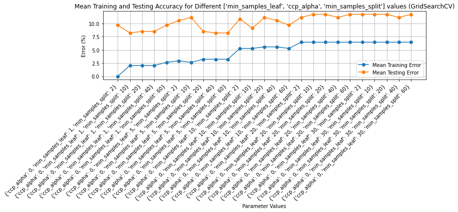

```python
#decision tree
best_params_f, cv_results_f, test_results_dict=decision_tree(X_train, y_train, X_test, y_test)
```

```
Random forest model performance before GridSearch: {'test_accuracy': 0.9605263157894737, 'precision': 0.9604625705593753, 'recall_score': 0.9605263157894737, 'f1_score': 0.9604745227642676}
Best Hyperparameters: {'max_features': 0.5, 'min_samples_leaf': 5, 'n_estimators': 500}
Test Results after GridSearch: {'test_accuracy': 0.9605263157894737, 'precision': 0.9606655527708159, 'recall_score': 0.9605263157894737, 'f1_score': 0.9605762069014403}
```

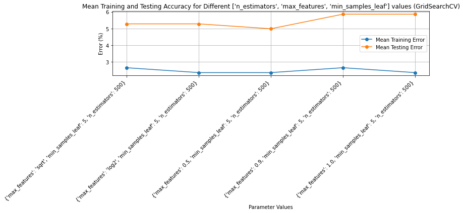

```python
#random forest
best_params_rf, cv_results_rf, test_results_dict_rf=random_forest(X_train, y_train, X_test, y_test)
```

```python
#knn
best_params_knn, cv_results_knn, test_results_dict_knn=knn_function(X_train, y_train, X_test, y_test)
```

[output not shown]

```
kNN model performance before GridSearch: {'test_accuracy': 0.9210526315789473, 'precision': 0.9207932966389297, 'recall_score': 0.9210526315789473, 'f1_score': 0.9206150296375861}
Best Hyperparameters: {'n_neighbors': 3, 'p': 1}
Test Results after GridSearch: {'test_accuracy': 0.9385964912280702, 'precision': 0.9385458165846184, 'recall_score': 0.9385964912280702, 'f1_score': 0.9382561341625667}
```

```
XGBoost model performance before GridSearch: {'test_accuracy': 0.9298245614035088, 'precision': 0.9298245614035088, 'recall_score': 0.9298245614035088, 'f1_score': 0.9298245614035088}
Best Hyperparameters: {'learning_rate': 0.5, 'max_depth': 5, 'n_estimators': 100}
Test Results after GridSearch: {'test_accuracy': 0.9517543859649122, 'precision': 0.9517188240872452, 'recall_score': 0.9517543859649122, 'f1_score': 0.9515573991197765}
```

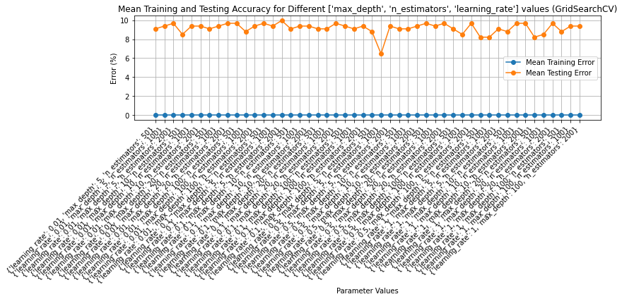

```python
#xgboost
best_params_xgb, cv_results_xgb, test_results_dict_xgb=xgboost_function(X_train, y_train, X_test, y_test)
```

# Task: Regression (with categorical features)

This represents a dataset crafted by Tony Pino, extracted from weekly publicly available results on Domain.com.au. Tony meticulously cleaned the data, and now it's your turn to unleash the power of data analysis. The dataset encompasses information such as Address, Real Estate Type, Suburb, Selling Method, Number of Rooms, Price, Real Estate Agent, Sale Date, and the distance from the Central Business District (C.B.D.).

Link: https://www.kaggle.com/datasets/dansbecker/melbourne-housing-snapshot

```python
data_housing = pd.read_csv('melb_data.csv')
data_housing.head()
```

|  | Suburb | Address | Rooms | Type | Price | Method | SellerG | Date | Distance | Postcode | ... | Bathroom | Car | Landsize | BuildingArea | YearBuilt | CouncilArea | Lattitude | Longtitude | Regionname | Propertycount |
| --- | --- | --- | --- | --- | --- | --- | --- | --- | --- | --- | --- | --- | --- | --- | --- | --- | --- | --- | --- | --- | --- |
| 0 | Abbotsford | 85 Turner St | 2 | h | 1480000.0 | S | Biggin | 3/12/2016 | 2.5 | 3067.0 | ... | 1.0 | 1.0 | 202.0 | NaN | NaN | Yarra | -37.7996 | 144.9984 | Northern Metropolitan | 4019.0 |
| 1 | Abbotsford | 25 Bloomburg St | 2 | h | 1035000.0 | S | Biggin | 4/02/2016 | 2.5 | 3067.0 | ... | 1.0 | 0.0 | 156.0 | 79.0 | 1900.0 | Yarra | -37.8079 | 144.9934 | Northern Metropolitan | 4019.0 |
| 2 | Abbotsford | 5 Charles St | 3 | h | 1465000.0 | SP | Biggin | 4/03/2017 | 2.5 | 3067.0 | ... | 2.0 | 0.0 | 134.0 | 150.0 | 1900.0 | Yarra | -37.8093 | 144.9944 | Northern Metropolitan | 4019.0 |
| 3 | Abbotsford | 40 Federation La | 3 | h | 850000.0 | PI | Biggin | 4/03/2017 | 2.5 | 3067.0 | ... | 2.0 | 1.0 | 94.0 | NaN | NaN | Yarra | -37.7969 | 144.9969 | Northern Metropolitan | 4019.0 |
| 4 | Abbotsford | 55a Park St | 4 | h | 1600000.0 | VB | Nelson | 4/06/2016 | 2.5 | 3067.0 | ... | 1.0 | 2.0 | 120.0 | 142.0 | 2014.0 | Yarra | -37.8072 | 144.9941 | Northern Metropolitan | 4019.0 |

5 rows × 21 columns

```python
data_housing.info()
```

```
<class 'pandas.core.frame.DataFrame'>
RangeIndex: 13580 entries, 0 to 13579
Data columns (total 21 columns):
 #   Column         Non-Null Count  Dtype
---  ------         --------------  -----
 0   Suburb         13580 non-null  object
 1   Address        13580 non-null  object
 2   Rooms          13580 non-null  int64
 3   Type           13580 non-null  object
 4   Price          13580 non-null  float64
 5   Method         13580 non-null  object
 6   SellerG        13580 non-null  object
 7   Date           13580 non-null  object
 8   Distance       13580 non-null  float64
 9   Postcode       13580 non-null  float64
 10  Bedroom2       13580 non-null  float64
 11  Bathroom       13580 non-null  float64
 12  Car            13518 non-null  float64
 13  Landsize       13580 non-null  float64
 14  BuildingArea   7130 non-null   float64
 15  YearBuilt      8205 non-null   float64
 16  CouncilArea    12211 non-null  object
 17  Lattitude      13580 non-null  float64
 18  Longtitude     13580 non-null  float64
 19  Regionname     13580 non-null  object
 20  Propertycount  13580 non-null  float64
dtypes: float64(12), int64(1), object(8)
memory usage: 2.2+ MB
```

```python
#nan check
data_housing.isna().sum()
```

```
Suburb              0
Address             0
Rooms               0
Type                0
Price               0
Method              0
SellerG             0
Date                0
Distance            0
Postcode            0
Bedroom2            0
Bathroom            0
Car                62
Landsize            0
BuildingArea     6450
YearBuilt        5375
CouncilArea      1369
Lattitude           0
Longtitude          0
Regionname          0
Propertycount       0
dtype: int64
```

```python
#first forwardfill thenbackward fill is  applied to fill missing values
data_housing = data_housing.fillna(method='ffill').fillna(method='bfill')
```

```python
#nan check after filing
data_housing.isna().sum()
```

```
Suburb           0
Address          0
Rooms            0
Type             0
Price            0
Method           0
SellerG          0
Date             0
Distance         0
Postcode         0
Bedroom2         0
Bathroom         0
Car              0
Landsize         0
BuildingArea     0
YearBuilt        0
CouncilArea      0
Lattitude        0
Longtitude       0
Regionname       0
Propertycount    0
dtype: int64
```

```python
#date column can be dropped since it wont be used, it is note a time series regresson task
data_housing.drop(columns=['Date'],inplace=True)
```

```python
data_housing.head()
```

|  | Suburb | Address | Rooms | Type | Price | Method | SellerG | Distance | Postcode | Bedroom2 | Bathroom | Car | Landsize | BuildingArea | YearBuilt | CouncilArea | Lattitude | Longtitude | Regionname | Propertycount |
| --- | --- | --- | --- | --- | --- | --- | --- | --- | --- | --- | --- | --- | --- | --- | --- | --- | --- | --- | --- | --- |
| 0 | Abbotsford | 85 Turner St | 2 | h | 1480000.0 | S | Biggin | 2.5 | 3067.0 | 2.0 | 1.0 | 1.0 | 202.0 | 79.0 | 1900.0 | Yarra | -37.7996 | 144.9984 | Northern Metropolitan | 4019.0 |
| 1 | Abbotsford | 25 Bloomburg St | 2 | h | 1035000.0 | S | Biggin | 2.5 | 3067.0 | 2.0 | 1.0 | 0.0 | 156.0 | 79.0 | 1900.0 | Yarra | -37.8079 | 144.9934 | Northern Metropolitan | 4019.0 |
| 2 | Abbotsford | 5 Charles St | 3 | h | 1465000.0 | SP | Biggin | 2.5 | 3067.0 | 3.0 | 2.0 | 0.0 | 134.0 | 150.0 | 1900.0 | Yarra | -37.8093 | 144.9944 | Northern Metropolitan | 4019.0 |
| 3 | Abbotsford | 40 Federation La | 3 | h | 850000.0 | PI | Biggin | 2.5 | 3067.0 | 3.0 | 2.0 | 1.0 | 94.0 | 150.0 | 1900.0 | Yarra | -37.7969 | 144.9969 | Northern Metropolitan | 4019.0 |
| 4 | Abbotsford | 55a Park St | 4 | h | 1600000.0 | VB | Nelson | 2.5 | 3067.0 | 3.0 | 1.0 | 2.0 | 120.0 | 142.0 | 2014.0 | Yarra | -37.8072 | 144.9941 | Northern Metropolitan | 4019.0 |

```python
categorical_columns = ['Suburb', 'Address','Type','Method', 'SellerG','CouncilArea','Regionname']
data_housing = pd.get_dummies(data_housing, columns=categorical_columns, drop_first=True)
```

```python
#split feature columns and target column
X = data_housing.drop(columns=['Price'])
y = data_housing['Price']
```

```python
#define train and test split
X_train, X_test, y_train, y_test = train_test_split(X, y, test_size=0.3)
```

```python
print("Training set size:", len(X_train))
print("Test set size:", len(X_test))
```

```
Training set size: 9506
Test set size: 4074
```

```python
rf_housing = RandomForestRegressor(n_jobs=-1)
rf_housing.fit(X_train,y_train)
```

```
RandomForestRegressor(n_jobs=-1)
```

```python
y_predict= rf_housing.predict(X_test)
```

```python
mse = mean_squared_error(y_test, y_predict)
print("Mean Squared Error:", mse)
```

```
Mean Squared Error: 0.13619117647058823
```

```python
param_grid_rf = {
     # Number of trees
    'n_estimators': [500],
    # Number of max_features
    'max_features': ['sqrt', 'log2', 0.5, 0.75, 0.9, 1.0],
    # Minimal number of observations per tree leaf
    'min_samples_leaf': [5],
}
```

```python
best_params_rf, cv_results_rf, test_results_dict_rf=perform_grid_search(rf_housing, param_grid_rf, X_train, y_train, X_test, y_test,scoring='neg_mean_squared_error',is_regression=True)
```

```
Best Hyperparameters: {'max_features': 0.75, 'min_samples_leaf': 5, 'n_estimators': 500}
Mean Squared Error after GridSearch: 0.13153963566711382
```

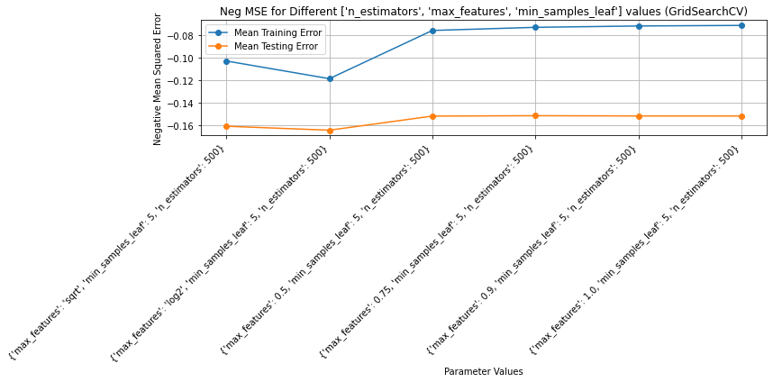

```python
plot_grid_search(cv_results_rf,param_grid_rf,is_regression=True)
```

```python
dt_housing = DecisionTreeRegressor(min_samples_leaf=5)
dt_housing.fit(X_train,y_train)
y_predict= dt_housing.predict(X_test)
```

```python
mse = mean_squared_error(y_test, y_predict)
print("Mean Squared Error Decision Tree:", mse)
```

```
Mean Squared Error Decision Tree: 140262996208.2151
```

```python
param_grid_dt = {
      # Minimal number of observations per tree leaf
    'min_samples_leaf': [1, 5, 10, 20, 30],
     # Complexity parameter set to zero as stated in assignment
    'ccp_alpha': [0],
     # Minimum number of observations to split
    'min_samples_split': [2, 10, 20, 40, 60] }
```

```python
best_params_dt, cv_results_dt, test_results_dict_dt=perform_grid_search(dt_housing, param_grid_dt, X_train, y_train, X_test, y_test,scoring='neg_mean_squared_error',is_regression=True)
```

```
Best Hyperparameters: {'ccp_alpha': 0, 'min_samples_leaf': 10, 'min_samples_split': 40}
Mean Squared Error after GridSearch: 118783256820.0927
```

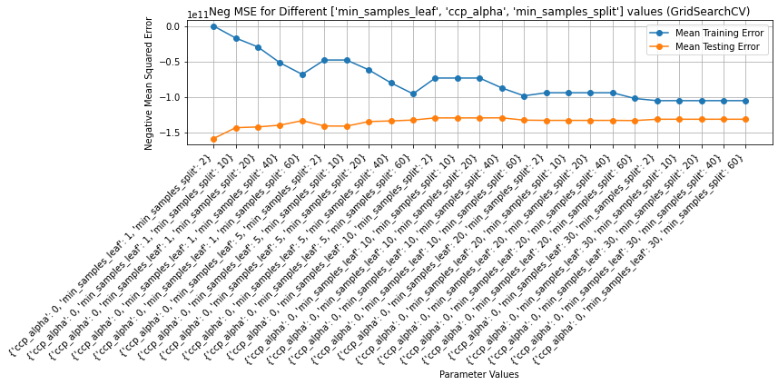

```python
plot_grid_search(cv_results_dt,param_grid_dt,is_regression=True)
```

```python
knn_housing = KNeighborsRegressor(n_neighbors=3)
knn_housing.fit(X_train,y_train)
y_predict= knn_housing.predict(X_test)
```

```python
mse = mean_squared_error(y_test, y_predict)
print("Mean Squared Error kNN:", mse)
```

```
Mean Squared Error kNN: 239181948962.00833
```

```python
param_grid_knn = {
    'n_neighbors': [3,10,20],
    'p': [1, 2] }
```

```python
best_params_knn, cv_results_knn, test_results_dict_knn=perform_grid_search(knn_housing, param_grid_knn, X_train, y_train, X_test, y_test,scoring='neg_mean_squared_error',is_regression=True)
```

[output not shown]

```python
plot_grid_search(cv_results_knn,param_grid_knn,is_regression=True)
```

[output not shown]

# Classification with more than 100 features

Myocardial Infarction (MI) complications Dataset link: https://archive.ics.uci.edu/dataset/579/myocardial+infarction+complications

```python
myocardial_infarction_complications = fetch_ucirepo(id=579)

X = myocardial_infarction_complications.data.features
y = myocardial_infarction_complications.data.targets['ZSN']
```

```python
X.head()
```

|  | AGE | SEX | INF_ANAM | STENOK_AN | FK_STENOK | IBS_POST | IBS_NASL | GB | SIM_GIPERT | DLIT_AG | ... | NOT_NA_1_n | NOT_NA_2_n | NOT_NA_3_n | LID_S_n | B_BLOK_S_n | ANT_CA_S_n | GEPAR_S_n | ASP_S_n | TIKL_S_n | TRENT_S_n |
| --- | --- | --- | --- | --- | --- | --- | --- | --- | --- | --- | --- | --- | --- | --- | --- | --- | --- | --- | --- | --- | --- |
| 0 | 77.0 | 1 | 2.0 | 1.0 | 1.0 | 2.0 | NaN | 3.0 | 0.0 | 7.0 | ... | 0.0 | 0.0 | 0.0 | 1.0 | 0.0 | 0.0 | 1.0 | 1.0 | 0.0 | 0.0 |
| 1 | 55.0 | 1 | 1.0 | 0.0 | 0.0 | 0.0 | 0.0 | 0.0 | 0.0 | 0.0 | ... | 1.0 | 0.0 | 0.0 | 1.0 | 0.0 | 1.0 | 1.0 | 1.0 | 0.0 | 1.0 |
| 2 | 52.0 | 1 | 0.0 | 0.0 | 0.0 | 2.0 | NaN | 2.0 | 0.0 | 2.0 | ... | 3.0 | 2.0 | 2.0 | 1.0 | 1.0 | 0.0 | 1.0 | 1.0 | 0.0 | 0.0 |
| 3 | 68.0 | 0 | 0.0 | 0.0 | 0.0 | 2.0 | NaN | 2.0 | 0.0 | 3.0 | ... | 0.0 | 0.0 | 0.0 | 0.0 | 0.0 | 1.0 | 1.0 | 1.0 | 0.0 | 0.0 |
| 4 | 60.0 | 1 | 0.0 | 0.0 | 0.0 | 2.0 | NaN | 3.0 | 0.0 | 7.0 | ... | 0.0 | 0.0 | 0.0 | 0.0 | 0.0 | 1.0 | 0.0 | 1.0 | 0.0 | 1.0 |

5 rows × 111 columns

```python
y.head()
```

```
0    0
1    0
2    0
3    1
4    0
Name: ZSN, dtype: int64
```

```python
#nan check before filing
X.isna().sum()
```

```
AGE             8
SEX             0
INF_ANAM        4
STENOK_AN     106
FK_STENOK      73
             ...
ANT_CA_S_n     13
GEPAR_S_n      17
ASP_S_n        17
TIKL_S_n       16
TRENT_S_n      16
Length: 111, dtype: int64
```

```python
#first forwardfill thenbackward fill is  applied to fill missing values
X= X.fillna(method='ffill').fillna(method='bfill')
```

```python
#nan check after filing
X.isna().sum()
```

```
AGE           0
SEX           0
INF_ANAM      0
STENOK_AN     0
FK_STENOK     0
             ..
ANT_CA_S_n    0
GEPAR_S_n     0
ASP_S_n       0
TIKL_S_n      0
TRENT_S_n     0
Length: 111, dtype: int64
```

```python
y
```

```
0       0
1       0
2       0
3       1
4       0
       ..
1695    0
1696    0
1697    0
1698    0
1699    0
Name: ZSN, Length: 1700, dtype: int64
```

```python
#define train and test split
X_train, X_test, y_train, y_test = train_test_split(X, y, test_size=0.3)
```

```python
print("Training set size:", len(X_train))
print("Test set size:", len(X_test))
```

```
Training set size: 1190
Test set size: 510
```

```
Decision Tree model performance before GridSearch: {'test_accuracy': 0.7372549019607844, 'precision': 0.7130174706196045, 'recall_score': 0.7372549019607844, 'f1_score': 0.7183801378073823}
Best Hyperparameters: {'ccp_alpha': 0, 'min_samples_leaf': 10, 'min_samples_split': 40}
Test Results after GridSearch: {'test_accuracy': 0.7666666666666667, 'precision': 0.7471798392838979, 'recall_score': 0.7666666666666667, 'f1_score': 0.7305734265734266}
```

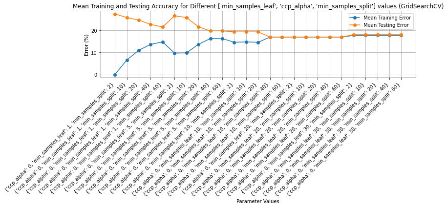

```python
#decision tree
best_params_f, cv_results_f, test_results_dict=decision_tree(X_train, y_train, X_test, y_test)
```

```
Random forest model performance before GridSearch: {'test_accuracy': 0.7450980392156863, 'precision': 0.7511190825192481, 'recall_score': 0.7450980392156863, 'f1_score': 0.6579039891818795}
Best Hyperparameters: {'max_features': 1.0, 'min_samples_leaf': 5, 'n_estimators': 500}
Test Results after GridSearch: {'test_accuracy': 0.7725490196078432, 'precision': 0.7784437564499485, 'recall_score': 0.7725490196078432, 'f1_score': 0.7187864044257456}
```

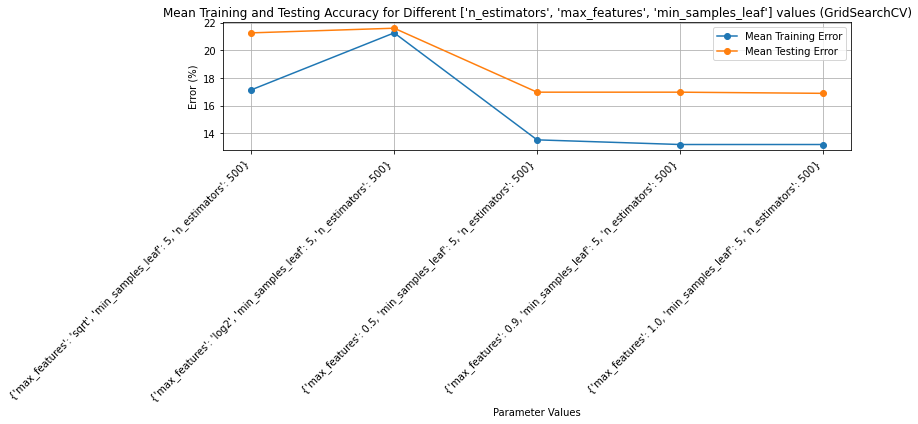

```python
#random forest
best_params_rf, cv_results_rf, test_results_dict_rf=random_forest(X_train, y_train, X_test, y_test)
```

```python
#knn
best_params_knn, cv_results_knn, test_results_dict_knn=knn_function(X_train, y_train, X_test, y_test)
```

[output not shown]

[output not shown]

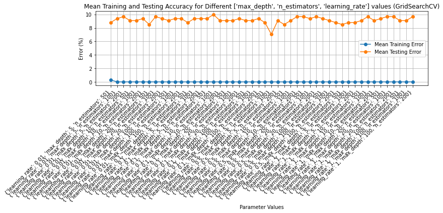

```python
#xgboost
best_params_xgb, cv_results_xgb, test_results_dict_xgb=xgboost_function(X_train, y_train, X_test, y_test)
```

# Classification (multiclass) with more than 100 features

The Street View House Numbers (SVHN) dataset is a collection of images of house numbers captured from Google Street View. Here is a summary of the SVHN dataset

```python
train = scipy.io.loadmat('train_32x32.mat')
test = scipy.io.loadmat('test_32x32.mat')
```

```python
y_train = keras.utils.to_categorical(train['y'][:,0])[:,1:]
y_test = keras.utils.to_categorical(test['y'][:,0])[:,1:]


y_train_flat = np.argmax(y_train, axis=1)
y_train_flat=y_train_flat[:30000]
y_test_flat = np.argmax(y_test, axis=1)
y_test_flat=y_test_flat[:5000]


X_train = np.zeros((73257, 32, 32, 3))
for i in range(len(X_train)):
    X_train[i] = train['X'].T[i].T.astype('float32')/255

X_test = np.zeros((26032, 32, 32, 3))
for i in range(len(X_test)):
    X_test[i] = test['X'].T[i].T.astype('float32')/255
```

```python
X_train_flat = X_train.reshape(X_train.shape[0], -1)
X_train_flat=X_train_flat[:30000,:]
X_test_flat = X_test.reshape(X_test.shape[0], -1)
X_test_flat=X_test_flat [:5000]
```

```python
print("Training set size:", len(X_train_flat))
print("Test set size:", len(X_test_flat))
```

```
Training set size: 30000
Test set size: 5000
```

```
Decision Tree model performance before GridSearch: {'test_accuracy': 0.4162, 'precision': 0.40970026665781234, 'recall_score': 0.4162, 'f1_score': 0.4119835089920714}
Best Hyperparameters: {'ccp_alpha': 0, 'min_samples_leaf': 10, 'min_samples_split': 40}
Test Results after GridSearch: {'test_accuracy': 0.4324, 'precision': 0.42427332492450803, 'recall_score': 0.4324, 'f1_score': 0.4266805307601534}
```

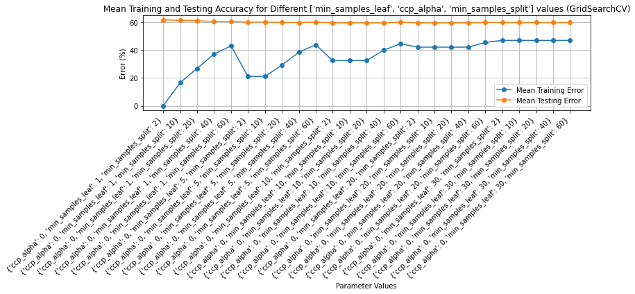

```python
#decision tree
best_params_f, cv_results_f, test_results_dict=decision_tree(X_train_flat, y_train_flat, X_test_flat, y_test_flat)
```

```python
#random forest
rf = RandomForestClassifier(n_estimators=500,min_samples_leaf=5,n_jobs=-1)
rf.fit(X_train_flat,y_train_flat)
y_predict= rf.predict(X_test_flat)

result=test_results(y_predict,y_test_flat)
print(f"""Random forest model performance before GridSearch: {result}""")
```

```
Random forest model performance before GridSearch: {'test_accuracy': 0.6476, 'precision': 0.6855673743998121, 'recall_score': 0.6476, 'f1_score': 0.6378303520780666}
```

```python
#knn
knn_classifier = KNeighborsClassifier(n_neighbors=3)
knn_classifier.fit(X_train_flat, y_train_flat)
y_predict= knn_classifier.predict(X_test_flat)
result=test_results(y_predict,y_test_flat)
print(f"""kNN model performance before GridSearch: {result}""")
```

```
kNN model performance before GridSearch: {'test_accuracy': 0.3966, 'precision': 0.3934617916158559, 'recall_score': 0.3966, 'f1_score': 0.36691208616155563}
```

```python
#xgboost
xgb = GradientBoostingClassifier(max_depth=30,n_estimators=100, learning_rate=10)

xgb.fit(X_train_flat,y_train_flat)

y_predict= xgb.predict(X_test_flat)
result=test_results(y_predict,y_test_flat)
print(f"""XGBoost model performance before GridSearch: {result}""")
```

Notes for some models on specific datasets.

-RandomForest for regression task with categorical features: This dataset contains categoricl and numerical values for Melbourne Housing Prices sucha as address, Price, Method, Landsize etc. Preprocessing should be applied for this dataset since it contains NaN values. Bacward anf froward filling methodology is applied. Categorical values should be converted to numerical values since RandomForecast do not accept categorical features. One-hot-encoding is applied. After this operation, the data_housing dataframe will have additional columns representing the one-hot-encoded categorical variables, and the original categorical columns will be removed. Each unique category in the original categorical columns will become a new binary column (0 or 1) in the df. Therefore, after one-hot encoding, column number has increased siginificantly. This has slowed down model creation and GridSearch processes.Best Hyperparameters are obtained as max_features 0.75, min_samples_leaf 5, n_estimators 500. Scoring is was set as neg_mean_squared_error and it has the value 0.13. After one hot encoding, feature importances could be considered to reduce feauture number before RandomForestRegressor creation.

-Decision tree with more than 100 fetaures: Decision treealgorithm is used to can make multi-class classification using a publicly available dataset “Street View House Numbers”. This dataset has 10 classes, 73257 digits for training and 26032 digits for testing and normlized pixel values are taken as faetures. The model fit and GridSearch times were too long compared to other models bacuse of feature space of the images are very high. I applied PCA to input array to decrease running time but accuracies were very low when transformed input rrays are used. Therefore, because of time constraints, no grid search is applied for this dataset except decision tree. Decision tree accuracy and grid search plot shows underfitting with high testing and training error. Another feature extraction methods such as histogram of oriented gradients or sobel edge detection can be applied to this dataset rather than using normalized pixel values in order to capture handwritten digits more accurately. Random forest results without grid search shows 20 % performance than decision tree, which is 64% test accuracy.